# Banks Stocks 2016~2022

## Visualizations

```python
sns.set_style('whitegrid')
import plotly
import cufflinks as cf
cf.go_offline()
```

Creating a distplot for JPMorgan Chase during 2022

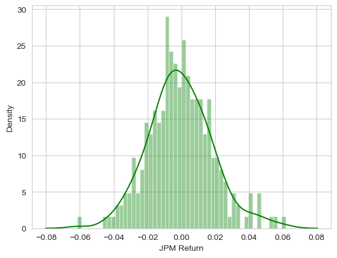

```python
sns.distplot(returns.loc['2022']['JPM Return'], color='green', bins=50)
```

Creating a distplot for Citigroup during 2008

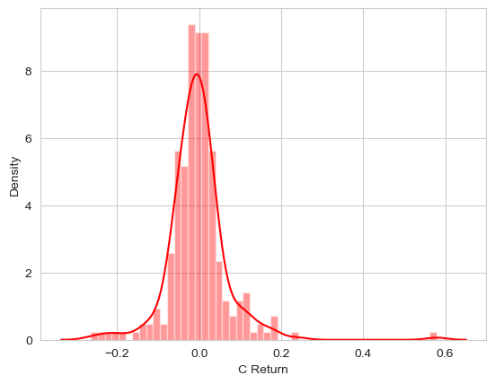

```python
sns.distplot(returns.loc['2008']['C Return'], color='red', bins=50)
```

**Creating a line plot showing Close price for each bank for the entire index of time**

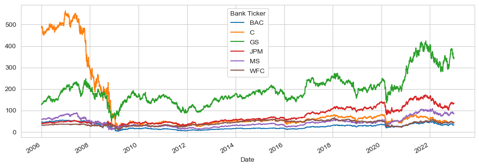

```python
bank_stocks.xs(key='Close', axis=1, level='Stock Info').plot(figsize=(12,4))
```

```python
bank_stocks.xs(key='Close', axis=1, level='Stock Info').iplot()
```

[interactive chart not shown]

## Moving Averages

Let's analyze the moving averages for these stocks in the year 2008.

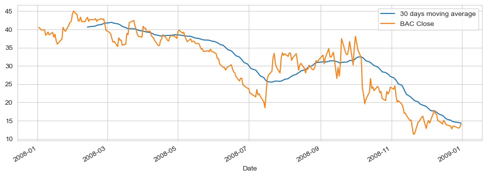

```python
plt.figure(figsize=(12,4))
BAC['Close'].loc['2008'].rolling(window=30).mean().plot(label='30 days moving average')
BAC['Close'].loc['2008'].plot(label='BAC Close')
plt.legend()
```

**Create a heatmap of the correlation between the stocks Close Price.**

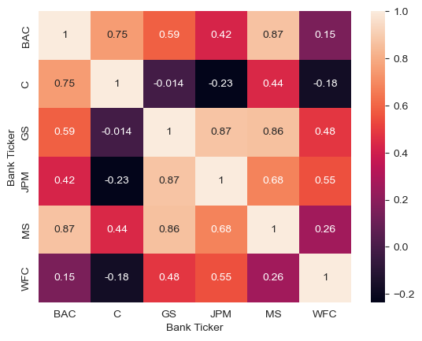

```python
sns.heatmap(bank_stocks.xs(key='Close', axis=1, level='Stock Info').corr(), annot=True)
```

```python
#!pip install scipy
```

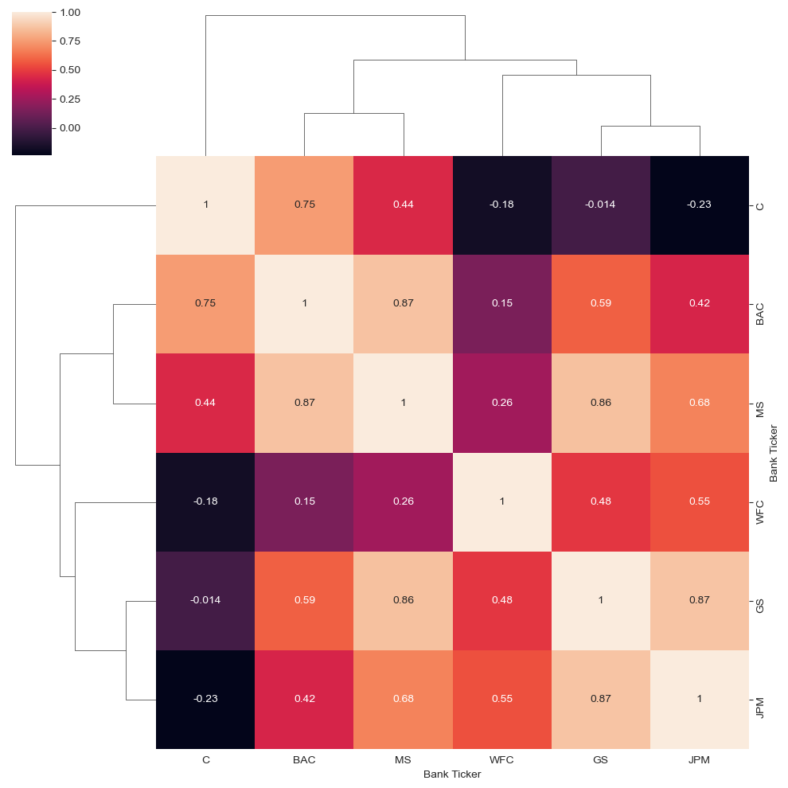

```python
sns.clustermap(bank_stocks.xs(key='Close',axis=1,level='Stock Info').corr(),annot=True)
```

```python
close_cor=bank_stocks.xs(key='Close',axis=1,level='Stock Info').corr()
```

**Creating a candle plot for BAC during 2015**

```python
bac15=BAC[['Open', 'High', 'Low', 'Close']].loc['2015']
bac15.iplot(kind='candle')
```

[interactive chart not shown]

**Using .ta_plot(study='sma') to create a Simple Moving Averages plot of Morgan Stanley for the year 2015.**

```python
MS['Close'].loc['2015'].ta_plot(study='sma', periods=[13,21,55])
```

[interactive chart not shown]

**Using .ta_plot(study='boll') to create a Bollinger Band Plot for Bank of America for the year 2015.**

```python
BAC['Close'].loc['2015'].ta_plot(study='boll')
```

[interactive chart not shown]